# Outside Item Memory

> This notebook focuses on item memory outside the rooms for the intermediate version.

# 1 Overview of the data

The rooms were separated into *Familiar* and *Novel* groups. Participants explored the *Familiar* group at the beginning of the experiment. In the encoding task, they visisted both *Familiar* and *Novel* groups. Their item memory (i.e., in which room they saw the item) was tested in the memory test the next day of the encoding task. **Novelty benefits** on the item memory are examined by comparing the memory performance between the *Familiar* and *Novel* groups.

Participants were also asked to rate how curious they felt about the room. The higher the rating is means they felt more curious about the room. Item memory as a function of curiosity rating was also examined for **curiosity benefits**.

In the encoding task, there were 6 objects in each room, and the participant saw the object after openning each of the six box. It is possbile that the item memory for the object to some extent depends on the order in which the object was seen. For example, it may be easier to remember where the first and last objects were seen as compared to those in the middle.

# 2 Visual inspection of the data

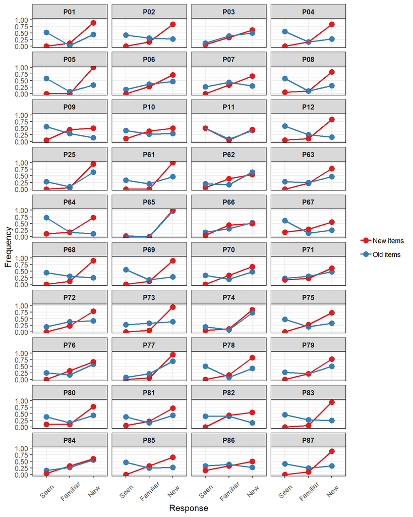

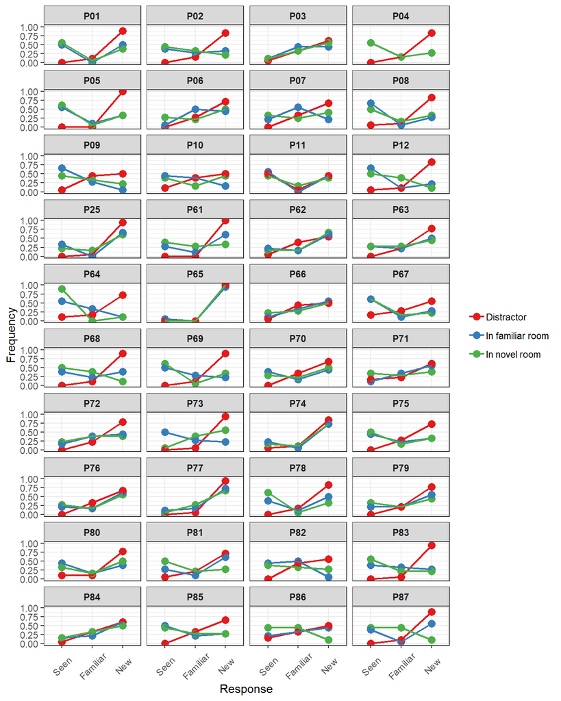

# 3 Novelty Benefits

We hypothesised that the memory for the items outside the rooms should be better for the *novel* rooms than for the *familiar* rooms.

## 3.1 Compare mean accuracy between *novel* and *familiar* rooms

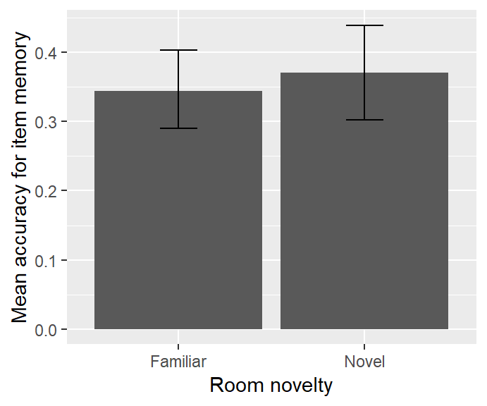

Figure1. Mean accuracy for item memory respectively for Familiar and Novel rooms.

```
##
##  Paired t-test
##
## data:  MeanSeenHit by Group
## t = -0.8991, df = 39, p-value = 0.3741
## alternative hypothesis: true difference in means is not equal to 0
## 95 percent confidence interval:
##  -0.06770168  0.02603501
## sample estimates:
## mean of the differences
##             -0.02083333
```

## 3.2 Item memory as a function of item order

### 3.2.1 Visualise the data

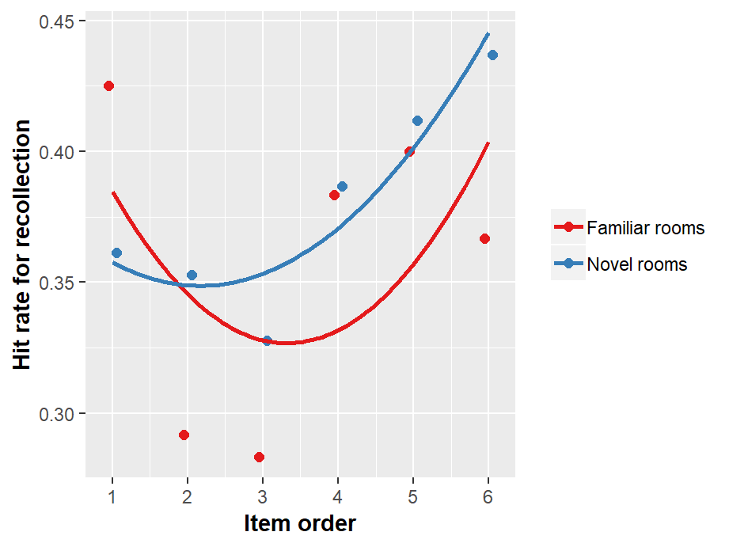

Figure 2. Mean hit rate of recollection at each order (i.e., 1st, 2nd, 3rd, etc), respectively for familiar and novel rooms.

### 3.2.2 Testing novelty effects by fitting mixed models

Build models with recollection hit rate as $y$ and examine effects of item order and novelty by including the predictors one by one and then comparing the models.

- `baseline.item` is the model with only an intercept.
- `order.model.linear.1` is the model with $\small ItemOrder$ included, showing the effects of item order.
- `order.model.linear.2` is the model allowing the slope (i.e., relationship between item memory and item order) varying across participants.
- `order.model.quad.1` and `order.model.quad.2` repectively included $\small ItemOrder^2$ and related random effects.
- `novelty.model.1` is the model with $\small Group$ (i.e., *familiar* and *novel* rooms) included, examining the effects of novelty of the rooms on the intercept (i.e., mean item memory accuracy at the 1st order or overall if no difference in slope).
- `novelty.model.2` is the model with interaction between $\small Group$ and $\small ItemOrder$ included, examining the effects of novelty on how item memory accuracy changes as a function of item order.
- `novelty.model.3` included interaction between $\small Group$ and $\small ItemOrder^2$ for inestigating whether the pattern changes between *familiar* and *novel* groups.

```
##                      Model df      AIC      BIC    logLik   Test  L.Ratio
## baseline.item            1  4 1909.611 1930.684 -950.8053
## order.model.linear.1     2  5 1909.368 1935.709 -949.6839 1 vs 2 2.242952
## order.model.linear.2     3  9 1917.362 1964.776 -949.6812 2 vs 3 0.005300
## order.model.quad.1       4 10 1916.181 1968.863 -948.0905 3 vs 4 3.181342
## novelty.model.1          5 11 1917.459 1975.410 -947.7297 4 vs 5 0.721596
## novelty.model.2          6 12 1918.524 1981.742 -947.2618 5 vs 6 0.935767
## novelty.model.3          7 13 1920.344 1988.831 -947.1721 6 vs 7 0.179418
##                      p-value
## baseline.item
## order.model.linear.1  0.1342
## order.model.linear.2  1.0000
## order.model.quad.1    0.0745
## novelty.model.1       0.3956
## novelty.model.2       0.3334
## novelty.model.3       0.6719
```

#### 3.2.2.1 Parameter estimation for the complete model

```
## Linear mixed-effects model fit by maximum likelihood
##  Data: Curiosity.Recall.Old
##        AIC      BIC    logLik
##   1920.344 1988.831 -947.1721
##
## Random effects:
##  Formula: ~1 + ItemOrder | SubjectNo
##  Structure: General positive-definite, Log-Cholesky parametrization
##             StdDev       Corr
## (Intercept) 1.467432e-01 (Intr)
## ItemOrder   5.666991e-05 -0.001
##
##  Formula: ~1 + ItemOrder | Group %in% SubjectNo
##  Structure: General positive-definite, Log-Cholesky parametrization
##             StdDev       Corr
## (Intercept) 0.0016328036 (Intr)
## ItemOrder   0.0000514436 -0.003
## Residual    0.4584367985
##
## Fixed effects: SeenHit ~ ItemOrder + I(ItemOrder^2) + Group + ItemOrder:Group +      I(ItemOrder^2):Group
##                                Value  Std.Error   DF   t-value p-value
## (Intercept)                0.4450000 0.07854042 1350  5.665872  0.0000
## ItemOrder                 -0.0711905 0.04907982 1350 -1.450504  0.1472
## I(ItemOrder^2)             0.0107143 0.00686358 1350  1.561034  0.1188
## GroupNovel                -0.0658014 0.10631863   39 -0.618908  0.5396
## ItemOrder:GroupNovel       0.0424990 0.06955502 1350  0.611013  0.5413
## I(ItemOrder^2):GroupNovel -0.0041116 0.00972694 1350 -0.422707  0.6726
##  Correlation:
##                           (Intr) ItmOrd I(ItO^2) GrpNvl ItO:GN
## ItemOrder                 -0.890
## I(ItemOrder^2)             0.816 -0.979
## GroupNovel                -0.674  0.657 -0.603
## ItemOrder:GroupNovel       0.628 -0.706  0.691   -0.931
## I(ItemOrder^2):GroupNovel -0.576  0.691 -0.706    0.854 -0.979
##
## Standardized Within-Group Residuals:
##        Min         Q1        Med         Q3        Max
## -1.5770220 -0.8137473 -0.4700888  1.0893867  2.0126419
##
## Number of Observations: 1434
## Number of Groups:
##            SubjectNo Group %in% SubjectNo
##                   40                   80
```

# 4 Curiosity Benefits

We hypothesed that the higher the curiosity rating was, the better the item memory should be.

## 4.1 Mean accuracy of item memory as a function of curiosity rating

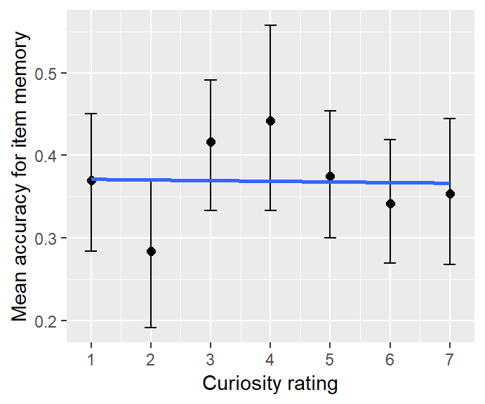

Figure 3. Mean accuracy for item memory as a function of curiosity rating.

However, the trend looks opposite to our prediction.

### 4.1.1 Testing the relationship between mean accuracy of item memory and curiosity rating

Build models with item memory accuracy as $y$ and examine effects of curiosity rating by including it into the model and then comparing the model fits.

- `baseline.rating` is the model with only an intercept, showing no change in item memory as a function of curiosity rating.
- `rating.intercept` is the model with $\small CuriosityRating$ included, showing the effects of curiosity rating.
- `rating.slope` is the model allowing the slope (i.e., relationship between item memory and curiosity rating) varying across participants.

```
##                  Model df      AIC      BIC    logLik   Test     L.Ratio
## baseline.rating      1  3 11.10149 21.53088 -2.550745
## rating.intercept     2  4 13.09533 27.00118 -2.547663 1 vs 2 0.006165182
## rating.slope         3  6 17.09986 37.95864 -2.549930 2 vs 3 0.004534773
##                  p-value
## baseline.rating
## rating.intercept  0.9374
## rating.slope      0.9977
```

#### 4.1.1.1 Parameter estimates in the complete model

```r
summary(rating.slope)
```

```
## Linear mixed-effects model fit by maximum likelihood
##  Data: OutsideObjectsMemory
##        AIC      BIC   logLik
##   17.09986 37.95864 -2.54993
##
## Random effects:
##  Formula: ~1 + CuriosityRating | SubjectNo
##  Structure: General positive-definite, Log-Cholesky parametrization
##                 StdDev       Corr
## (Intercept)     0.1387750021 (Intr)
## CuriosityRating 0.0009281722 -0.029
## Residual        0.2210087608
##
## Fixed effects: SeenHit ~ CuriosityRating
##                      Value  Std.Error  DF   t-value p-value
## (Intercept)      0.3709341 0.03964146 198  9.357227  0.0000
## CuriosityRating -0.0005721 0.00731671 198 -0.078190  0.9378
##  Correlation:
##                 (Intr)
## CuriosityRating -0.748
##
## Standardized Within-Group Residuals:
##         Min          Q1         Med          Q3         Max
## -2.08215978 -0.63088058 -0.04812393  0.65807264  2.79184155
##
## Number of Observations: 239
## Number of Groups: 40
```

#### 4.1.1.2 Plot the model

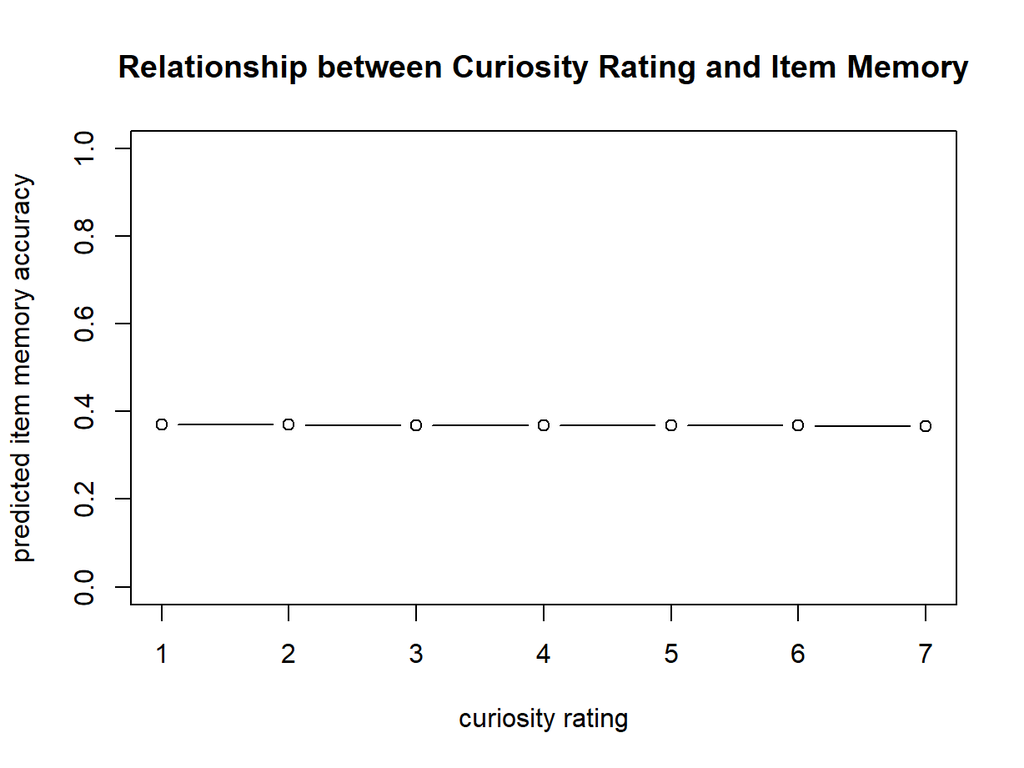

## 4.2 Does the relationship with curiosity rating depend on item order?

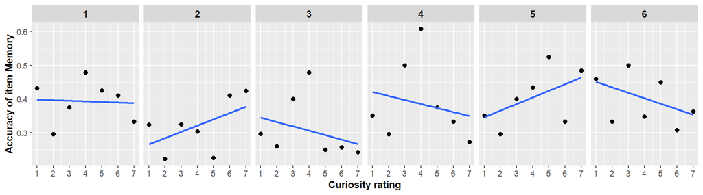

Figure 4. Mean accuracy across participants for item memory as a function of curiosity rating for each order at which the item was seen (I.e., 1st, 2nd, 3rd, etc.).

### 4.2.1 Testing the effect of item order

Build models with context memory accuracy as $y$ and examine effects of curiosity rating and item order by comparing the models.

- `item.model.linear.1` is the model with $\small ItemOrder$ included (in addition to $\small CuriosityRating$), showing the effects of item order.
- `item.model.linear.2` is the model allowing the slope (i.e., relationship between item memory and item order) varying across participants.
- `item.model.linear.3` is the model with the interaction between $\small ItemOrders$ and $\small CuriosityRating$ included.
- `item.model.quad.1` and `item.model.quad.2` repectively included $\small ItemOrder^2$ and related random effects.
- `item.model.quad.3` included interaction between $\small ItemOrder^2$ and $\small CuriosityRating$ for inestigating whether the pattern changes as a function of *curiosity rating*.

```r
baseline.item <- lme(SeenHit ~ 1, random = ~ 1|SubjectNo, data = Curiosity.Recall.Old, method = "ML", control = list(msMaxIter = 500, opt = "optim", msVerbose=FALSE), na.action = na.exclude)

rating.intercept <- update(baseline.item, .~. + CuriosityRating)
rating.slope     <- update(rating.intercept, random = ~ 1 + CuriosityRating | SubjectNo)

item.model.linear.1     <- update(rating.slope, .~. + ItemOrder)
item.model.linear.2     <- update(item.model.linear.1, random = list(~1+CuriosityRating+ItemOrder|SubjectNo))
item.model.linear.3     <- update(item.model.linear.2, .~. + ItemOrder : CuriosityRating)

item.model.quad.1       <- update(item.model.linear.3, .~. + I(ItemOrder^2))
# item.model.quad.2       <- update(item.model.quad.1,   random = list(~1+CuriosityRating|SubjectNo, ~1+ItemOrder+I(ItemOrder^2)|SubjectNo)) - excluding this model because singularity issue (perhaps the model was getting too complex to be calculated)
item.model.quad.3       <- update(item.model.quad.1,   .~. + I(ItemOrder^2) : CuriosityRating)

anova(rating.intercept, rating.slope, item.model.linear.1, item.model.linear.2, item.model.linear.3, item.model.quad.1, item.model.quad.3)
```

```
##                     Model df      AIC      BIC    logLik   Test  L.Ratio
## rating.intercept        1  4 1909.597 1930.670 -950.7984
## rating.slope            2  6 1913.599 1945.208 -950.7994 1 vs 2 0.001907
## item.model.linear.1     3  7 1913.355 1950.233 -949.6778 2 vs 3 2.243276
## item.model.linear.2     4 10 1919.355 1972.037 -949.6774 3 vs 4 0.000638
## item.model.linear.3     5 11 1921.047 1978.998 -949.5237 4 vs 5 0.307487
## item.model.quad.1       6 12 1919.865 1983.084 -947.9326 5 vs 6 3.182183
## item.model.quad.3       7 13 1921.820 1990.307 -947.9101 6 vs 7 0.045006
##                     p-value
## rating.intercept
## rating.slope         0.9990
## item.model.linear.1  0.1342
## item.model.linear.2  1.0000
## item.model.linear.3  0.5792
## item.model.quad.1    0.0744
## item.model.quad.3    0.8320
```

#### 4.2.1.1 Parameter estimation for the complete model

```r
summary(item.model.quad.3)
```

```
## Linear mixed-effects model fit by maximum likelihood
##  Data: Curiosity.Recall.Old
##       AIC      BIC    logLik
##   1921.82 1990.307 -947.9101
##
## Random effects:
##  Formula: ~1 + CuriosityRating + ItemOrder | SubjectNo
##  Structure: General positive-definite, Log-Cholesky parametrization
##                 StdDev       Corr
## (Intercept)     0.1471123204 (Intr) CrstyR
## CuriosityRating 0.0028759399 -0.071
## ItemOrder       0.0002190246 -0.002 -0.006
## Residual        0.4586440564
##
## Fixed effects: SeenHit ~ CuriosityRating + ItemOrder + I(ItemOrder^2) + CuriosityRating:ItemOrder +      CuriosityRating:I(ItemOrder^2)
##                                     Value  Std.Error   DF   t-value
## (Intercept)                     0.4060500 0.12167296 1389  3.337224
## CuriosityRating                 0.0015245 0.02640143 1389  0.057743
## ItemOrder                      -0.0565996 0.07801496 1389 -0.725497
## I(ItemOrder^2)                  0.0107345 0.01091003 1389  0.983908
## CuriosityRating:ItemOrder       0.0016221 0.01724030 1389  0.094086
## CuriosityRating:I(ItemOrder^2) -0.0005104 0.00241098 1389 -0.211716
##                                p-value
## (Intercept)                     0.0009
## CuriosityRating                 0.9540
## ItemOrder                       0.4683
## I(ItemOrder^2)                  0.3253
## CuriosityRating:ItemOrder       0.9251
## CuriosityRating:I(ItemOrder^2)  0.8324
##  Correlation:
##                                (Intr) CrstyR ItmOrd I(IO^2 CrR:IO
## CuriosityRating                -0.879
## ItemOrder                      -0.913  0.832
## I(ItemOrder^2)                  0.837 -0.763 -0.979
## CuriosityRating:ItemOrder       0.817 -0.930 -0.895  0.876
## CuriosityRating:I(ItemOrder^2) -0.749  0.852  0.876 -0.895 -0.979
##
## Standardized Within-Group Residuals:
##        Min         Q1        Med         Q3        Max
## -1.5763115 -0.8172959 -0.4666387  1.0955034  2.0085810
##
## Number of Observations: 1434
## Number of Groups: 40
```

Maybe because of being lack of power (too many parameters and too few participants), no parameter has a significant estimated value.

### 4.2.2 Collapse the order and curiosity rating

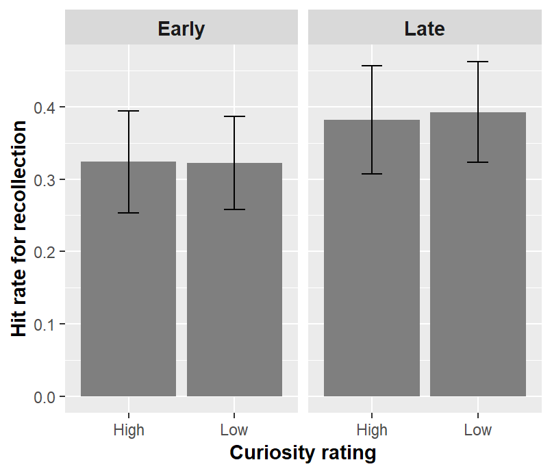

Figure 7. Mean hit rate as a function of item order (Early vs. Late) and curiosity (Low vs. High).

#### 4.2.2.1 Stats on it

```
## Linear mixed-effects model fit by maximum likelihood
##  Data: Curiosity.Recall.Old.Collapsed
##         AIC       BIC   logLik
##   -67.02908 -42.63024 41.51454
##
## Random effects:
##  Formula: ~1 | SubjectNo
##         (Intercept)
## StdDev:   0.1422527
##
##  Formula: ~1 | CuriosityRatingType %in% SubjectNo
##         (Intercept)
## StdDev:    0.062609
##
##  Formula: ~1 | ItemOrderType %in% CuriosityRatingType %in% SubjectNo
##         (Intercept)   Residual
## StdDev:   0.1357617 0.05000805
##
## Fixed effects: SeenHit ~ CuriosityRatingType * ItemOrderType
##                                               Value  Std.Error DF
## (Intercept)                               0.3237500 0.03401260 76
## CuriosityRatingTypeLow                   -0.0047163 0.03633471 37
## ItemOrderTypeLate                         0.0581944 0.03277413 76
## CuriosityRatingTypeLow:ItemOrderTypeLate  0.0119810 0.04695552 76
##                                            t-value p-value
## (Intercept)                               9.518531  0.0000
## CuriosityRatingTypeLow                   -0.129801  0.8974
## ItemOrderTypeLate                         1.775621  0.0798
## CuriosityRatingTypeLow:ItemOrderTypeLate  0.255156  0.7993
##  Correlation:
##                                          (Intr) CrsRTL ItmOTL
## CuriosityRatingTypeLow                   -0.516
## ItemOrderTypeLate                        -0.482  0.451
## CuriosityRatingTypeLow:ItemOrderTypeLate  0.336 -0.646 -0.698
##
## Standardized Within-Group Residuals:
##          Min           Q1          Med           Q3          Max
## -0.734918254 -0.231054445 -0.007305022  0.195663141  0.767653542
##
## Number of Observations: 156
## Number of Groups:
##                                             SubjectNo
##                                                    40
##                    CuriosityRatingType %in% SubjectNo
##                                                    78
## ItemOrderType %in% CuriosityRatingType %in% SubjectNo
##                                                   156
```

### 4.2.3 Try another way to calculate “High” and “Low” curiosity groups

> “High” - higher than mean; “Low” - lower than mean

#### 4.2.3.1 Compare “High” and “Low” groups

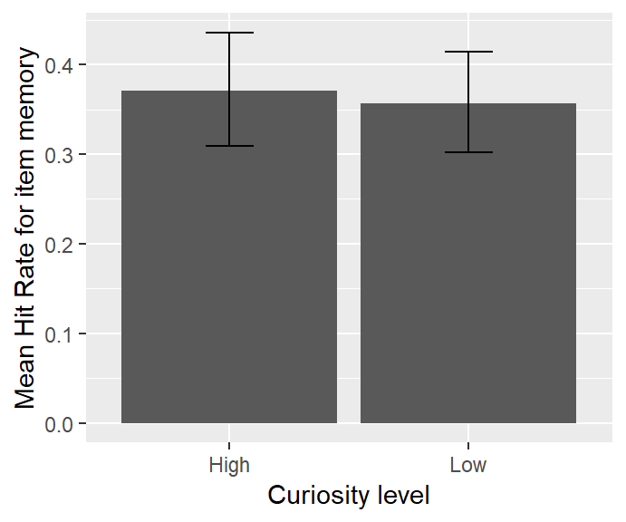

```
##
##  Paired t-test
##
## data:  SeenHit by RatingGroup
## t = 0.49323, df = 39, p-value = 0.6246
## alternative hypothesis: true difference in means is not equal to 0
## 95 percent confidence interval:
##  -0.04414431  0.07261653
## sample estimates:
## mean of the differences
##              0.01423611
```

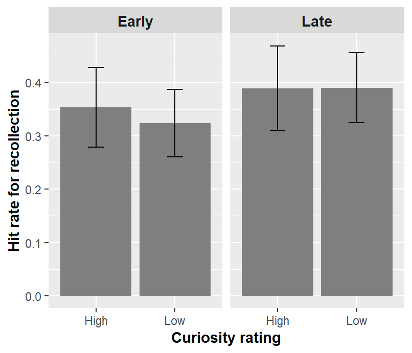

#### 4.2.3.2 Stats on it

```
## Linear mixed-effects model fit by maximum likelihood
##  Data: Curiosity.Recall.Old.Collapsed.Alt[!SubjectNo %in% bad.ps.less.strict]
##         AIC       BIC   logLik
##   -49.78774 -25.18635 32.89387
##
## Random effects:
##  Formula: ~1 | SubjectNo
##         (Intercept)
## StdDev:    0.138797
##
##  Formula: ~1 | RatingGroup %in% SubjectNo
##         (Intercept)
## StdDev:  0.06016937
##
##  Formula: ~1 | ItemOrderType %in% RatingGroup %in% SubjectNo
##         (Intercept)   Residual
## StdDev:   0.1501653 0.05195224
##
## Fixed effects: SeenHit ~ RatingGroup * ItemOrderType
##                                       Value  Std.Error DF   t-value
## (Intercept)                       0.3534722 0.03513112 78 10.061514
## RatingGroupLow                   -0.0298611 0.03847677 39 -0.776082
## ItemOrderTypeLate                 0.0354167 0.03598337 78  0.984251
## RatingGroupLow:ItemOrderTypeLate  0.0312500 0.05088817 78  0.614092
##                                  p-value
## (Intercept)                       0.0000
## RatingGroupLow                    0.4424
## ItemOrderTypeLate                 0.3280
## RatingGroupLow:ItemOrderTypeLate  0.5409
##  Correlation:
##                                  (Intr) RtngGL ItmOTL
## RatingGroupLow                   -0.548
## ItemOrderTypeLate                -0.512  0.468
## RatingGroupLow:ItemOrderTypeLate  0.362 -0.661 -0.707
##
## Standardized Within-Group Residuals:
##          Min           Q1          Med           Q3          Max
## -0.786481225 -0.204375481  0.001502109  0.174403846  1.001079742
##
## Number of Observations: 160
## Number of Groups:
##                                     SubjectNo
##                                            40
##                    RatingGroup %in% SubjectNo
##                                            80
## ItemOrderType %in% RatingGroup %in% SubjectNo
##                                           160
```

# 5 Curiosity and novelty

## 5.1 Testing the effects of curiosity rating and novelty together

Build models with recollection hit rate as $y$ and examine effects of curiosity rating and novelty together by including them into the model separately and then comparing the model fits.

```
##                   Model df      AIC      BIC    logLik   Test   L.Ratio
## baseline.rating       1  4 13.10402 27.00987 -2.552010
## rating.intercept      2  5 15.10101 32.48333 -2.550504 1 vs 2 0.0030122
## rating.slope          3  9 23.09645 54.38462 -2.548224 2 vs 3 0.0045610
## novelty.model         4 10 24.37481 59.13944 -2.187404 3 vs 4 0.7216394
## interaction.model     5 11 26.33168 64.57278 -2.165839 4 vs 5 0.0431300
##                   p-value
## baseline.rating
## rating.intercept   0.9562
## rating.slope       1.0000
## novelty.model      0.3956
## interaction.model  0.8355
```

### 5.1.1 Check the complete model

```
## Linear mixed-effects model fit by maximum likelihood
##  Data: OutsideObjectsMemory
##        AIC      BIC    logLik
##   26.33168 64.57278 -2.165839
##
## Random effects:
##  Formula: ~1 + CuriosityRating | SubjectNo
##  Structure: General positive-definite, Log-Cholesky parametrization
##                 StdDev       Corr
## (Intercept)     1.394552e-01 (Intr)
## CuriosityRating 5.923265e-05 -0.002
##
##  Formula: ~1 + CuriosityRating | Group %in% SubjectNo
##  Structure: General positive-definite, Log-Cholesky parametrization
##                 StdDev       Corr
## (Intercept)     8.579748e-04 (Intr)
## CuriosityRating 3.577056e-05 -0.002
## Residual        2.204578e-01
##
## Fixed effects: SeenHit ~ CuriosityRating + Group + CuriosityRating:Group
##                                 Value  Std.Error  DF   t-value p-value
## (Intercept)                 0.3627356 0.05304146 157  6.838718  0.0000
## CuriosityRating            -0.0013865 0.01375409 157 -0.100809  0.9198
## GroupNovel                  0.0452217 0.09235859  39  0.489631  0.6271
## CuriosityRating:GroupNovel -0.0044806 0.02149114 157 -0.208486  0.8351
##  Correlation:
##                            (Intr) CrstyR GrpNvl
## CuriosityRating            -0.823
## GroupNovel                 -0.626  0.658
## CuriosityRating:GroupNovel  0.661 -0.802 -0.937
##
## Standardized Within-Group Residuals:
##         Min          Q1         Med          Q3         Max
## -2.11363298 -0.64334923 -0.07307903  0.65966560  2.87839541
##
## Number of Observations: 239
## Number of Groups:
##            SubjectNo Group %in% SubjectNo
##                   40                   80
```

## 5.2 What about the other way around

```
##                   Model df      AIC      BIC    logLik   Test   L.Ratio
## baseline.rating       1  4 13.10402 27.00987 -2.552010
## novelty.model         2  5 14.58150 31.96382 -2.290751 1 vs 2 0.5225183
## rating.model.1        3  6 16.37990 37.23868 -2.189949 2 vs 3 0.2016044
## rating.model.2        4 10 24.37481 59.13944 -2.187404 3 vs 4 0.0050899
## interaction.model     5 11 26.33168 64.57278 -2.165839 4 vs 5 0.0431300
##                   p-value
## baseline.rating
## novelty.model      0.4698
## rating.model.1     0.6534
## rating.model.2     1.0000
## interaction.model  0.8355
```

### 5.2.1 Check the model

```
## Linear mixed-effects model fit by maximum likelihood
##  Data: OutsideObjectsMemory
##        AIC      BIC    logLik
##   26.33168 64.57278 -2.165839
##
## Random effects:
##  Formula: ~1 + CuriosityRating | SubjectNo
##  Structure: General positive-definite, Log-Cholesky parametrization
##                 StdDev       Corr
## (Intercept)     0.1394552015 (Intr)
## CuriosityRating 0.0000592326 -0.002
##
##  Formula: ~1 + CuriosityRating | Group %in% SubjectNo
##  Structure: General positive-definite, Log-Cholesky parametrization
##                 StdDev       Corr
## (Intercept)     8.579746e-04 (Intr)
## CuriosityRating 3.577054e-05 -0.002
## Residual        2.204578e-01
##
## Fixed effects: SeenHit ~ Group + CuriosityRating + Group:CuriosityRating
##                                 Value  Std.Error  DF   t-value p-value
## (Intercept)                 0.3627356 0.05304146 157  6.838718  0.0000
## GroupNovel                  0.0452217 0.09235859  39  0.489631  0.6271
## CuriosityRating            -0.0013865 0.01375409 157 -0.100809  0.9198
## GroupNovel:CuriosityRating -0.0044806 0.02149114 157 -0.208486  0.8351
##  Correlation:
##                            (Intr) GrpNvl CrstyR
## GroupNovel                 -0.626
## CuriosityRating            -0.823  0.658
## GroupNovel:CuriosityRating  0.661 -0.937 -0.802
##
## Standardized Within-Group Residuals:
##         Min          Q1         Med          Q3         Max
## -2.11363298 -0.64334923 -0.07307903  0.65966560  2.87839541
##
## Number of Observations: 239
## Number of Groups:
##            SubjectNo Group %in% SubjectNo
##                   40                   80
```

## 5.3 Check the collapsed data

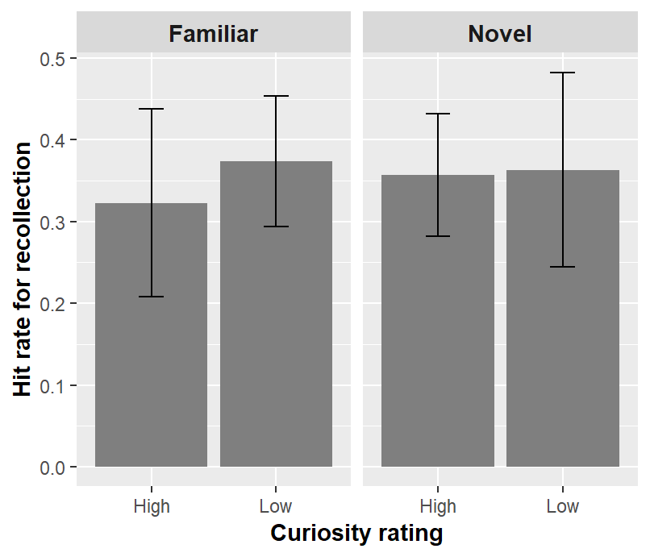

#### 5.3.0.1 Stats on it

```
## Linear mixed-effects model fit by maximum likelihood
##  Data: Curiosity.Recall.Old.Collapsed.Interaction[!SubjectNo %in% bad.ps.less.strict]
##        AIC       BIC   logLik
##   -24.1703 -3.823945 20.08515
##
## Random effects:
##  Formula: ~1 | SubjectNo
##         (Intercept)
## StdDev:   0.1307831
##
##  Formula: ~1 | CuriosityRatingType %in% SubjectNo
##         (Intercept)
## StdDev: 0.001048025
##
##  Formula: ~1 | Group %in% CuriosityRatingType %in% SubjectNo
##         (Intercept)   Residual
## StdDev:   0.1598832 0.01184435
##
## Fixed effects: SeenHit ~ CuriosityRatingType * Group
##                                       Value  Std.Error DF  t-value p-value
## (Intercept)                       0.3444285 0.04982729 39 6.912446  0.0000
## CuriosityRatingTypeLow            0.0207893 0.05556270 37 0.374160  0.7104
## GroupNovel                        0.0101977 0.05611861 14 0.181717  0.8584
## CuriosityRatingTypeLow:GroupNovel 0.0085985 0.08885480 14 0.096771  0.9243
##  Correlation:
##                                   (Intr) CrsRTL GrpNvl
## CuriosityRatingTypeLow            -0.769
## GroupNovel                        -0.767  0.730
## CuriosityRatingTypeLow:GroupNovel  0.575 -0.734 -0.748
##
## Standardized Within-Group Residuals:
##           Min            Q1           Med            Q3           Max
## -0.1332865716 -0.0439780804 -0.0004380176  0.0344488170  0.2509272945
##
## Number of Observations: 94
## Number of Groups:
##                                     SubjectNo
##                                            40
##            CuriosityRatingType %in% SubjectNo
##                                            78
## Group %in% CuriosityRatingType %in% SubjectNo
##                                            94
```

### 5.3.1 Alternative way to collapse data

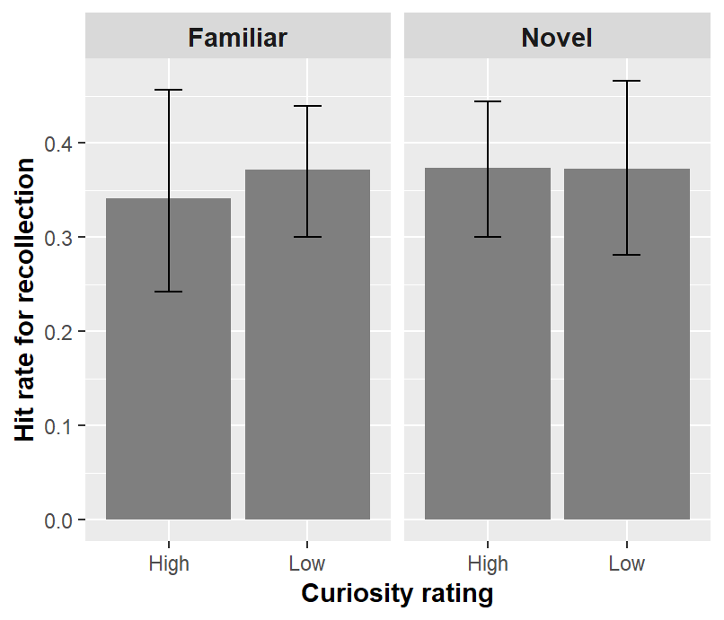

```
## Linear mixed-effects model fit by maximum likelihood
##  Data: Curiosity.Recall.Old.Collapsed.Alt.Interaction[!SubjectNo %in%      bad.ps.less.strict]
##         AIC       BIC   logLik
##   -25.70178 -5.186994 20.85089
##
## Random effects:
##  Formula: ~1 | SubjectNo
##         (Intercept)
## StdDev:   0.1237298
##
##  Formula: ~1 | RatingGroup %in% SubjectNo
##         (Intercept)
## StdDev:   0.0822041
##
##  Formula: ~1 | Group %in% RatingGroup %in% SubjectNo
##         (Intercept)   Residual
## StdDev:    0.135643 0.04712917
##
## Fixed effects: SeenHit ~ RatingGroup * Group
##                               Value  Std.Error DF  t-value p-value
## (Intercept)               0.3650755 0.05186340 39 7.039175  0.0000
## RatingGroupLow            0.0004126 0.05746530 39 0.007179  0.9943
## GroupNovel                0.0034100 0.05536467 14 0.061591  0.9518
## RatingGroupLow:GroupNovel 0.0128023 0.08394635 14 0.152506  0.8810
##  Correlation:
##                           (Intr) RtngGL GrpNvl
## RatingGroupLow            -0.793
## GroupNovel                -0.782  0.737
## RatingGroupLow:GroupNovel  0.598 -0.730 -0.758
##
## Standardized Within-Group Residuals:
##          Min           Q1          Med           Q3          Max
## -0.776196007 -0.166217827 -0.005703416  0.132526237  0.919123990
##
## Number of Observations: 96
## Number of Groups:
##                             SubjectNo
##                                    40
##            RatingGroup %in% SubjectNo
##                                    80
## Group %in% RatingGroup %in% SubjectNo
##                                    96
```

# 6 Curiosity effects in the *Novel* group

## 6.1 Mean accuracy of item memory as a function of curiosity rating

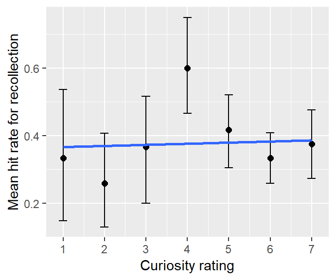